# **Rapport statistique sur un jeu de données**

YIFEI WANG, M1 MIASHS-C2ES

2020-11-01

### **Description**

- **Sujet : “*French Train stats*” ->** [Source](https://github.com/Da11tura/tidytuesday/tree/master/data/2019/2019-02-26)
- **Packages utilisées**

```r
library(nycflights13)
library(tidyverse)
library(ggthemes)
library(ggplot2)
library(skimr)
library(dplyr)
library(broom)
```

- **Import data original**

```r
tgv <- readr::read_csv("https://raw.githubusercontent.com/rfordatascience/tidytuesday/master/data/2019/2019-02-26/full_trains.csv")
```

- **Description des données**

  Cet ensemble de données présente les annulations et les retards de TGV, ainsi que les causes des retards, sur la période 2015-2018. Il contient un total de 5462 observations et 27 variables.

### **Traiter le tableau**

Tout d’abord, j’ai traité l’ensemble de données original, et j’ai obtenu deux sous-tableaux `tgv_sncf` et `pourquoi_taux`.

- **Sous-tableau 1 : `tgv_sncf`**

```r
tgv %>%
  mutate(nombre_trains = total_num_trips - num_of_canceled_trains,
         taux_retard_departure = num_late_at_departure / nombre_trains * 100,
         taux_retard_arrival = num_arriving_late / nombre_trains * 100) %>%
  select(year, month, nombre_trains, service, journey_time_avg, total_num_trips, num_of_canceled_trains,
         contains("departure"), contains("departing"), contains("arrival"),
         contains("arriving"),-contains("comment")) -> tgv_sncf

tgv_sncf
```

```
# A tibble: 5,462 x 17
    year month nombre_trains service journey_time_avg total_num_trips
   <dbl> <dbl>         <dbl> <chr>              <dbl>           <dbl>
 1  2017     9           299 Nation…             85.1             299
 2  2017     9           217 Nation…             47.1             218
 3  2017     9           332 Nation…            116.              333
 4  2017     9           480 Nation…            161.              481
 5  2017     9           190 Nation…            164.              190
 6  2017     9           190 Nation…            129.              191
 7  2017     9           208 Nation…            184.              208
 8  2017     9           214 Nation…            186.              216
 9  2017     9           660 Nation…            121.              661
10  2017     9           201 Nation…             97.4             201
# … with 5,452 more rows, and 11 more variables: num_of_canceled_trains <dbl>,
#   departure_station <chr>, num_late_at_departure <dbl>,
#   avg_delay_late_at_departure <dbl>, taux_retard_departure <dbl>,
#   avg_delay_all_departing <dbl>, arrival_station <chr>,
#   avg_delay_late_on_arrival <dbl>, taux_retard_arrival <dbl>,
#   num_arriving_late <dbl>, avg_delay_all_arriving <dbl>
```

C’est une explication des certains variables ：

| Nom de colonnes | Explication |
| --- | --- |
| journey_time_avg | Temps de trajet moyen (minutes) |
| total_num_trips | Nombre total de trains au cours de la période |
| num_late_at_departure | Nombre de trains en retard au départ |
| avg_delay_late_at_departure | Temps moyen (minutes) pour les trains en retard au départ |
| avg_delay_all_departing | Temps moyen (minutes) pour tous les trains au départ |
| num_arriving_late | Nombre de trains arrivant en retard |
| avg_delay_late_on_arrive | Temps moyen (minutes) pour les trains en retard à l’arrivée |
| avg_delay_all_arriving | Délai moyen (minutes) pour tous les trains arrivant |

- **Sous-tableau 2 : `pourquoi_taux`**

```r
tgv %>%
  select(year, month, starts_with("delay_cause_")) %>%
  summarise(external_cause = mean(delay_cause_external_cause, na.rm = T)*100,
            rail_infrastructure = mean(delay_cause_rail_infrastructure, na.rm = T)*100,
            traffic_management = mean(delay_cause_traffic_management, na.rm = T)*100,
            rolling_stock = mean(delay_cause_rolling_stock, na.rm = T)*100,
            station_management = mean(delay_cause_station_management, na.rm = T)*100,
            travelers = mean(delay_cause_travelers, na.rm = T)*100) %>%
  pivot_longer(everything(), names_to = "Raisons", values_to = "taux") %>%
  mutate(label_p = paste(Raisons, '(', round(taux, 2), '%)', sep = ''),
         type = factor(label_p,levels=label_p)) %>%
  arrange(-taux) -> pourquoi_taux

pourquoi_taux
```

```
# A tibble: 6 x 4
  Raisons              taux label_p                    type
  <chr>               <dbl> <chr>                      <fct>
1 external_cause      27.8  external_cause(27.8%)      external_cause(27.8%)
2 rail_infrastructure 25.2  rail_infrastructure(25.18… rail_infrastructure(25.1…
3 traffic_management  18.3  traffic_management(18.31%) traffic_management(18.31…
4 rolling_stock       17.9  rolling_stock(17.88%)      rolling_stock(17.88%)
5 station_management   7.00 station_management(7%)     station_management(7%)
6 travelers            3.73 travelers(3.73%)           travelers(3.73%)
```

Ce tableau décrit les causes des retards de train :

| Les causes | Explication |
| --- | --- |
| delay_cause_external_cause | Les externes (météo, colis suspects, grève etc) |
| delay_cause_rail_infrastructure | L’infrastructure ferroviaire (travaux) |
| delay_cause_traffic_management | La gestion tarif (intéraction réseaux) |
| delay_cause_rolling_stock | Le matériel roulant |
| delay_cause_station_management | La gestion en gare et réutilisation de matériel |
| delay_cause_travelers | Prise en compte voyageurs (affluence) |

### **Questions**

#### Question 1 : Quelle année est une mauvaise année en termes d’annulation de trains?

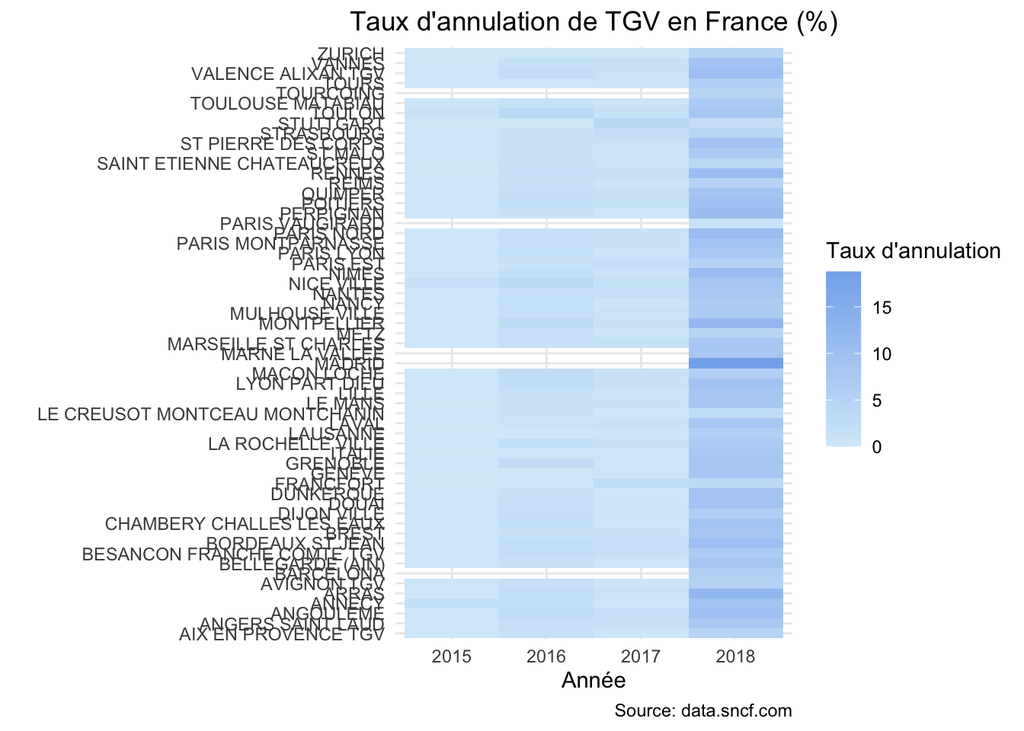

```r
tgv_sncf %>%
  group_by(year, departure_station) %>%
  summarise(sum_annulation = sum(num_of_canceled_trains, na.rm = T), sum_total = sum(total_num_trips, na.rm = T),
    taux_annulation = 100*sum_annulation/sum_total) %>%
  mutate(year = as.factor(year)) %>%
  ggplot(aes(x = year, y = departure_station)) +
  geom_tile(aes(fill = taux_annulation)) +
  labs(x = "Année", y = "",fill = "Taux d'annulation", title = "Taux d'annulation de TGV en France (%)",
       caption  = "Source: data.sncf.com") +
  scale_fill_gradient(low = "#d6ecfa", high = "#84B1ED") +
  theme_minimal() +
  theme(plot.title = element_text(hjust = 0.5))
```

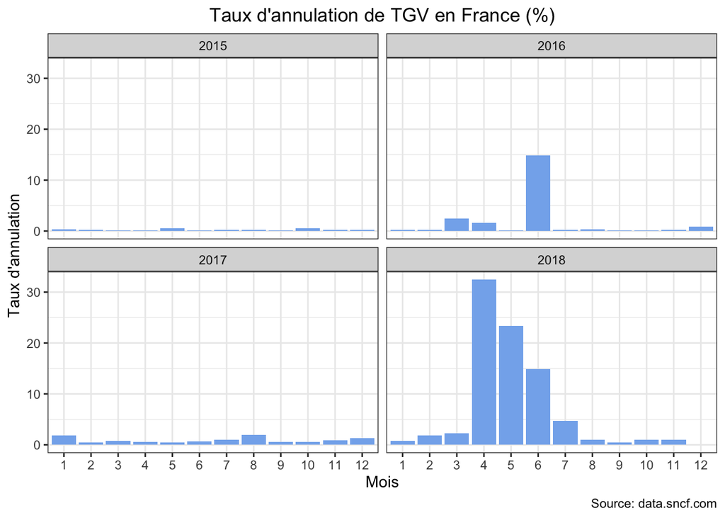

```r
tgv_sncf %>%
  group_by(year, month) %>%
  mutate(taux_annulation = mean(num_of_canceled_trains/total_num_trips*100, na.rm = T),
         month = as.factor(month)) %>%
  ggplot(aes(x = month, y = taux_annulation)) +
  geom_bar(position="dodge", stat="identity", fill = "#84B1ED") +
  theme_bw() +
  facet_wrap(~year) +
  coord_cartesian(xlim = c(1, 12)) +
  labs(x="Mois", y="Taux d'annulation", title = "Taux d'annulation de TGV en France (%)",
       caption = "Source: data.sncf.com") +
  theme(plot.title = element_text(hjust = 0.5))
```

#### Question 2 : Quel gare a le taux d’annulation plus élevé, en 2015-2017?

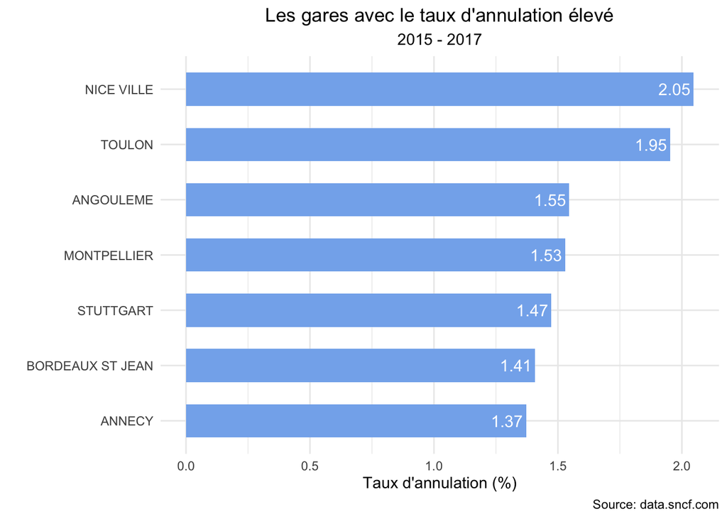

```r
tgv_sncf %>%
  filter(year != 2018) %>%
  group_by(departure_station) %>%
  summarise(sum_annulation = sum(num_of_canceled_trains, na.rm = T), sum_total = sum(total_num_trips, na.rm = T),
            taux_annulation = 100*sum_annulation/sum_total) %>%
  arrange(-taux_annulation) %>%
  slice(1:7) %>%
  ggplot(aes(x = taux_annulation, y = reorder(departure_station,taux_annulation))) +
  geom_bar(position="dodge", stat="identity", fill = "#84B1ED", width = 0.6) +
  geom_text(mapping = aes(label = round(taux_annulation,2)), size = 4,
            vjust = 0.5, hjust = 1.1, colour = "white") +
  labs(x = "Taux d'annulation (%)", y = "", title = "Les gares avec le taux d'annulation élevé",
       subtitle = "2015 - 2017", caption  = "Source: data.sncf.com") +
  scale_fill_gradient(low = "#d6ecfa", high = "#84B1ED") +
  theme_minimal() +
  theme(plot.title = element_text(hjust = 0.5), plot.subtitle = element_text(hjust = 0.5))
```

#### Question 3 : En 2015-2018, quel mois a la taux de retard plus élevé?

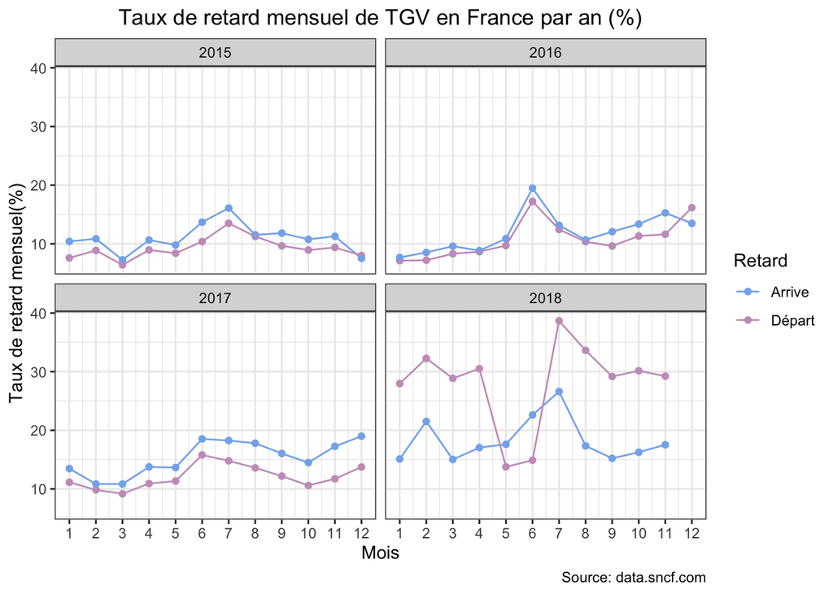

```r
tgv_sncf %>%
  group_by(year, month) %>%
  summarise(moyenne_retard_dep = mean(taux_retard_departure, na.rm = T),
            moyenne_retard_arr = mean(taux_retard_arrival, na.rm = T)) %>%
  select(year, month, moyenne_retard_dep, moyenne_retard_arr) %>%
  pivot_longer(cols = !year & !month, names_to = "retard", values_to = "moyenne_taux") %>%
  ggplot(aes(x = month, y = moyenne_taux, col = retard)) +
  geom_point() +
  geom_line() +
  scale_x_continuous(breaks = seq(0, 12, 1)) +
  facet_wrap(~year) +
  scale_color_manual(values=c("#84B1ED", "#C89EC4"),
                     name="Retard",labels=c("Arrive", "Départ")) +
  labs(x="Mois", y="Taux de retard mensuel(%)",
       title = "Taux de retard mensuel de TGV en France par an (%)",
       caption = "Source: data.sncf.com") +
  theme_bw() +
  theme(plot.title = element_text(hjust = 0.5))
```